# 相関係数の課題と正答例

藤野秀則,

2025-02-02

# 1 課題1

NHK受信料支払率とコロナ感染者数,高齢化率についてのデータこちらについて，以下の課題を行え

1. head()とsummary()を使ってデータの概要を確認せよ
2. NHK受信料とコロナ患者数
3. 高齢化率とNHK受信料
4. 高齢化率とコロナ患者数

```r
data <- read.csv("./practice/example_09_Corona_NHK.csv")

# 1.
head(data)
```

```
##   都道府県 NHK支払率 コロナ患者数 高齢化率
## 1     愛知      81.9     181980.1     25.5
## 2     愛媛      83.4     124436.4     33.6
## 3     茨城      84.3     128402.5     30.1
## 4     岡山      84.8     147931.3     30.6
## 5     沖縄      49.5     341064.0     23.1
## 6     岩手      94.6      92130.4     34.2
```

```r
summary(data)
```

```
##    都道府県           NHK支払率      コロナ患者数       高齢化率
##  Length:47          Min.   :49.50   Min.   : 92130   Min.   :22.90
##  Class :character   1st Qu.:81.65   1st Qu.:124660   1st Qu.:29.60
##  Mode  :character   Median :84.10   Median :147931   Median :31.30
##                     Mean   :83.50   Mean   :153711   Mean   :31.11
##                     3rd Qu.:87.45   3rd Qu.:170217   3rd Qu.:33.40
##                     Max.   :97.90   Max.   :341064   Max.   :38.10
```

```r
# 2. NHK受信料とコロナ感染者数
cor(data$NHK支払率, data$コロナ患者数)
```

```
## [1] -0.8516341
```

```r
#3. 高齢化率とNHK受信料
cor(data$高齢化率, data$NHK支払率)
```

```
## [1] 0.6804925
```

```r
#4. 高齢化率とコロナ感染症
cor(data$高齢化率, data$コロナ患者数)
```

```
## [1] -0.6138787
```

# 2 課題2

先ほどのコロナ感染者数とNHK受信料支払世帯のデータについて，高齢化率を統制した場合の偏相関を求めよ．

```r
library(ppcor)
data <- read.csv("./practice/example_09_Corona_NHK.csv")
head(data)
```

```
##   都道府県 NHK支払率 コロナ患者数 高齢化率
## 1     愛知      81.9     181980.1     25.5
## 2     愛媛      83.4     124436.4     33.6
## 3     茨城      84.3     128402.5     30.1
## 4     岡山      84.8     147931.3     30.6
## 5     沖縄      49.5     341064.0     23.1
## 6     岩手      94.6      92130.4     34.2
```

```r
# 偏相関
Res.pcor<-pcor.test(data$NHK支払率,
               data$コロナ患者数,
               data$高齢化率)
print(Res.pcor)
```

```
##     estimate      p.value statistic  n gp  Method
## 1 -0.7501149 1.964756e-09 -7.524032 47  1 pearson
```

# 3 課題3

このデータは高校生における対人依存欲求（他者と親密な関係を築くことで自身の心の安定を得るとともに，問題に直面したときに他者に助けを求めようとする欲求）と，SNSの利用時間との関係を調べたものである．

1. このデータにhead()とsummary()を適用し，データの概要を把握せよ．
2. このデータの散布図を作成せよ．
3. このデータを用いて，対人依存欲求とSNSの利用時間の間の相関係数を求めよ．
4. このデータの「性別」を要因型に変換し，男性と女性のそれぞれのデータを抽出してsummary()を適用し，それぞれのデータの概要を把握せよ.
5. 先ほど作成した散布図を男女別に色分けした散布図にせよ．
6. 男女別で，対人依存欲求とSNSの利用時間の相関係数を求めよ．

```r
library(tidyverse)
data <- read.csv("./practice/example_09_HiddenCorrel.csv")

# 1.
head(data)
```

```
##   性別 対人依存欲求 SNS利用時間
## 1   男          3.1        80.8
## 2   男          3.3         6.8
## 3   男          1.4        70.8
## 4   男          2.0        26.8
## 5   男          2.9        48.8
## 6   男          2.0        26.8
```

```r
summary(data)
```

```
##      性別            対人依存欲求    SNS利用時間
##  Length:283         Min.   :1.000   Min.   :-73.20
##  Class :character   1st Qu.:2.100   1st Qu.: 28.80
##  Mode  :character   Median :2.900   Median : 60.80
##                     Mean   :2.863   Mean   : 61.41
##                     3rd Qu.:3.500   3rd Qu.: 91.85
##                     Max.   :5.000   Max.   :213.90
```

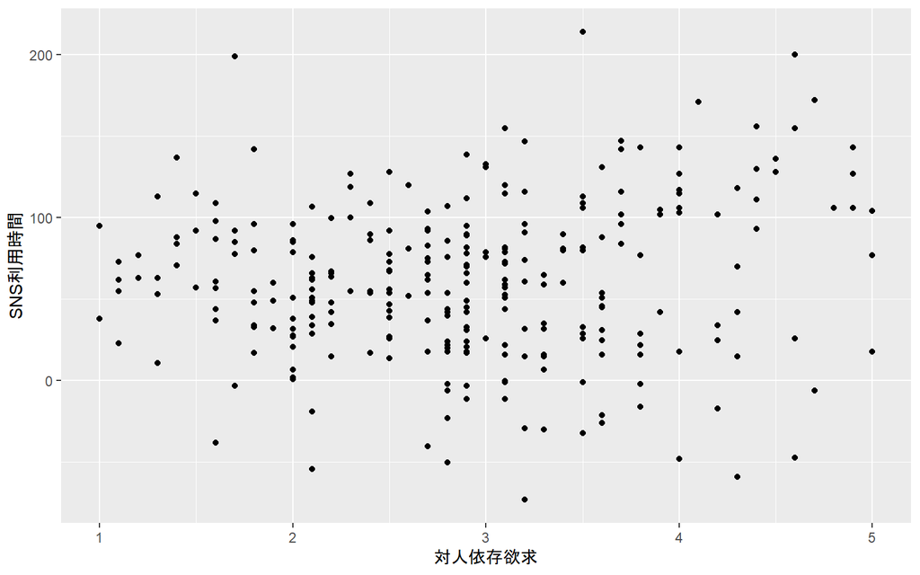

```r
# 2.
g<-ggplot(data, aes(x=対人依存欲求, y=SNS利用時間)) + geom_point()
plot(g)
```

```r
# 3.
cor(data$対人依存欲求, data$SNS利用時間)
```

```
## [1] 0.1089131
```

```r
# 4.
data$性別 <-as.factor(data$性別)
男性 <- filter(data, 性別 == "男")
女性 <- filter(data, 性別 == "女")

summary(男性)
```

```
##  性別      対人依存欲求    SNS利用時間
##  女:  0   Min.   :1.000   Min.   :-73.20
##  男:161   1st Qu.:2.100   1st Qu.: 15.80
##           Median :2.900   Median : 33.80
##           Mean   :2.795   Mean   : 39.81
##           3rd Qu.:3.300   3rd Qu.: 69.80
##           Max.   :5.000   Max.   :198.80
```

```r
summary(女性)
```

```
##  性別      対人依存欲求    SNS利用時間
##  女:122   Min.   :1.000   Min.   : 25.90
##  男:  0   1st Qu.:2.200   1st Qu.: 62.15
##           Median :2.900   Median : 85.90
##           Mean   :2.953   Mean   : 89.91
##           3rd Qu.:3.700   3rd Qu.:110.40
##           Max.   :5.000   Max.   :213.90
```

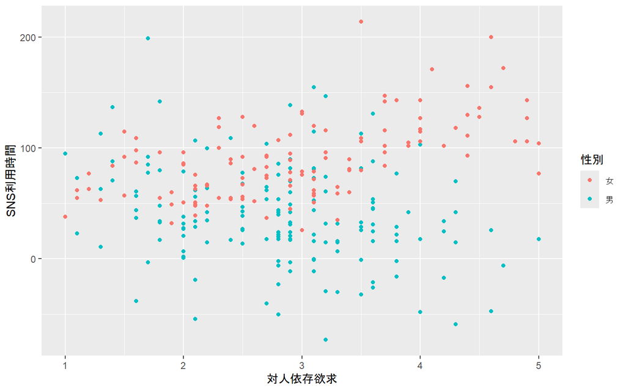

```r
# 5.
g<-ggplot(data, aes(x=対人依存欲求, y=SNS利用時間, color=性別)) + geom_point()
plot(g)
```

```r
# 6.
cor(男性$対人依存欲求, 男性$SNS利用時間)
```

```
## [1] -0.2637511
```

```r
cor(女性$対人依存欲求, 女性$SNS利用時間)
```

```
## [1] 0.5671742
```

# 4 課題4

ある組織で従業員満足度調査として，従業員323名（課長級以上の管理職は除く）に対して以下の項目について調査した．

- Q1: 直属の上司のリーダーシップの評価（7段階評価）
- Q2: 自身の職務内容に対する満足度（7段階評価）
- Q3: 自身の給与に対する満足度（7段階評価）
- Q4: 所属している部署の雰囲気に対する満足度（7段階評価）
- F1: 所属部署（13の部署からの選択）
- F2: 性別（男女）
- F3: 年齢（20歳から65歳まで5年区切り）

その結果，次のようなデータが得られた．このデータについて以下の課題を行え．

1. Q1からQ4について，部署ごとの平均と標準偏差を求めよ（参考）．
2. Q1からQ4について，データ全体での相関行列を求めよ．
3. データ全体でのQ1とQ2の相関とQ1とQ3の相関に有意な差があるかどうかを検定せよ．
4. 営業部におけるQ1からQ4の相関行列を求めよ．
5. 営業部におけるQ1とQ4の相関と，開発部におけるQ1とQ4の相関に有意な差があるかどうかを検定せよ．
6. 営業部におけるQ1とQ4の相関と，同じく営業部におけるQ2とQ3の相関に有意な差があるかどうかを検定せよ．

## 4.1 1

```r
data <- read.csv("./practice/09_work_Cor.csv")

# Q1からQ4について，部署ごとの平均と標準偏差を求めよ
aggregate(Q1~F1, data, mean)
```

```
##                    F1       Q1
## 1    マーケティング部 3.950000
## 2              営業部 4.040000
## 3              開発部 3.720000
## 4          経営企画室 4.000000
## 5              経理部 3.600000
## 6          資材調達部 3.777778
## 7  情報システム管理部 3.666667
## 8              人事部 4.083333
## 9              製造部 3.830000
## 10             総務部 3.916667
## 11         品質管理部 3.933333
## 12             法務部 3.500000
## 13         流通管理部 3.850000
```

```r
aggregate(Q1~F1, data, sd)
```

```
##                    F1       Q1
## 1    マーケティング部 1.050063
## 2              営業部 1.049003
## 3              開発部 1.242310
## 4          経営企画室 1.414214
## 5              経理部 1.638815
## 6          資材調達部 1.395605
## 7  情報システム管理部 1.188177
## 8              人事部 1.083625
## 9              製造部 1.231366
## 10             総務部 1.378954
## 11         品質管理部 1.162919
## 12             法務部 1.069045
## 13         流通管理部 1.386969
```

```r
aggregate(Q2~F1, data, mean)
```

```
##                    F1       Q2
## 1    マーケティング部 4.050000
## 2              営業部 3.940000
## 3              開発部 3.760000
## 4          経営企画室 3.600000
## 5              経理部 3.733333
## 6          資材調達部 3.944444
## 7  情報システム管理部 3.833333
## 8              人事部 3.833333
## 9              製造部 3.730000
## 10             総務部 3.583333
## 11         品質管理部 3.866667
## 12             法務部 3.875000
## 13         流通管理部 3.900000
```

```r
aggregate(Q2~F1, data, sd)
```

```
##                    F1       Q2
## 1    マーケティング部 1.099043
## 2              営業部 1.150155
## 3              開発部 1.331666
## 4          経営企画室 1.429841
## 5              経理部 1.222799
## 6          資材調達部 1.258955
## 7  情報システム管理部 1.424574
## 8              人事部 1.193416
## 9              製造部 1.339795
## 10             総務部 1.311372
## 11         品質管理部 1.355764
## 12             法務部 1.125992
## 13         流通管理部 1.252366
```

```r
aggregate(Q3~F1, data, mean)
```

```
##                    F1       Q3
## 1    マーケティング部 4.450000
## 2              営業部 4.440000
## 3              開発部 4.280000
## 4          経営企画室 4.200000
## 5              経理部 4.266667
## 6          資材調達部 4.333333
## 7  情報システム管理部 4.277778
## 8              人事部 4.333333
## 9              製造部 4.220000
## 10             総務部 4.083333
## 11         品質管理部 4.266667
## 12             法務部 4.250000
## 13         流通管理部 4.350000
```

```r
aggregate(Q3~F1, data, sd)
```

```
##                    F1        Q3
## 1    マーケティング部 0.9986833
## 2              営業部 1.0333224
## 3              開発部 1.2754084
## 4          経営企画室 1.0327956
## 5              経理部 1.1629192
## 6          資材調達部 1.1375929
## 7  情報システム管理部 1.1274936
## 8              人事部 1.0730867
## 9              製造部 1.1856039
## 10             総務部 1.2401124
## 11         品質管理部 1.3345233
## 12             法務部 1.0350983
## 13         流通管理部 1.1367081
```

```r
aggregate(Q4~F1, data, mean)
```

```
##                    F1       Q4
## 1    マーケティング部 4.600000
## 2              営業部 4.460000
## 3              開発部 4.360000
## 4          経営企画室 4.400000
## 5              経理部 4.266667
## 6          資材調達部 4.388889
## 7  情報システム管理部 4.388889
## 8              人事部 4.250000
## 9              製造部 4.270000
## 10             総務部 4.250000
## 11         品質管理部 4.266667
## 12             法務部 4.375000
## 13         流通管理部 4.400000
```

```r
aggregate(Q4~F1, data, sd)
```

```
##                    F1        Q4
## 1    マーケティング部 0.8825800
## 2              営業部 0.8854838
## 3              開発部 1.1503623
## 4          経営企画室 1.0749677
## 5              経理部 1.2227993
## 6          資材調達部 0.9785276
## 7  情報システム管理部 0.9785276
## 8              人事部 0.9653073
## 9              製造部 1.0717210
## 10             総務部 0.9653073
## 11         品質管理部 1.0997835
## 12             法務部 1.0606602
## 13         流通管理部 1.0462967
```

```r
# 別解
data %>%
  group_by(F1) %>%
  summarise(across(c(Q1:Q4), list(M=mean,SD=sd)))
```

```
## # A tibble: 13 × 9
##    F1                  Q1_M Q1_SD  Q2_M Q2_SD  Q3_M Q3_SD  Q4_M Q4_SD
##    <chr>              <dbl> <dbl> <dbl> <dbl> <dbl> <dbl> <dbl> <dbl>
##  1 マーケティング部    3.95  1.05  4.05  1.10  4.45 0.999  4.6  0.883
##  2 人事部              4.08  1.08  3.83  1.19  4.33 1.07   4.25 0.965
##  3 品質管理部          3.93  1.16  3.87  1.36  4.27 1.33   4.27 1.10
##  4 営業部              4.04  1.05  3.94  1.15  4.44 1.03   4.46 0.885
##  5 情報システム管理部  3.67  1.19  3.83  1.42  4.28 1.13   4.39 0.979
##  6 法務部              3.5   1.07  3.88  1.13  4.25 1.04   4.38 1.06
##  7 流通管理部          3.85  1.39  3.9   1.25  4.35 1.14   4.4  1.05
##  8 経営企画室          4     1.41  3.6   1.43  4.2  1.03   4.4  1.07
##  9 経理部              3.6   1.64  3.73  1.22  4.27 1.16   4.27 1.22
## 10 総務部              3.92  1.38  3.58  1.31  4.08 1.24   4.25 0.965
## 11 製造部              3.83  1.23  3.73  1.34  4.22 1.19   4.27 1.07
## 12 資材調達部          3.78  1.40  3.94  1.26  4.33 1.14   4.39 0.979
## 13 開発部              3.72  1.24  3.76  1.33  4.28 1.28   4.36 1.15
```

## 4.2 2

```r
# Q1からQ4について，データ全体での相関行列を求めよ
cor(data[,c("Q1","Q2","Q3","Q4")])
```

```
##           Q1        Q2        Q3        Q4
## Q1 1.0000000 0.3342396 0.1777939 0.3128059
## Q2 0.3342396 1.0000000 0.2492102 0.2858166
## Q3 0.1777939 0.2492102 1.0000000 0.2043669
## Q4 0.3128059 0.2858166 0.2043669 1.0000000
```

## 4.3 3

```r
# データ全体でのQ1とQ2の相関とQ1とQ3の相関に有意な差があるかどうかを検定せよ
library(cocor)
cocor.dep.groups.overlap(cor(data$Q1, data$Q2), cor(data$Q1, data$Q3), cor(data$Q2, data$Q3), nrow(data))
```

```
##
##   Results of a comparison of two overlapping correlations based on dependent groups
##
## Comparison between r.jk = 0.3342 and r.jh = 0.1778
## Difference: r.jk - r.jh = 0.1564
## Related correlation: r.kh = 0.2492
## Group size: n = 323
## Null hypothesis: r.jk is equal to r.jh
## Alternative hypothesis: r.jk is not equal to r.jh (two-sided)
## Alpha: 0.05
##
## pearson1898: Pearson and Filon's z (1898)
##   z = 2.4225, p-value = 0.0154
##   Null hypothesis rejected
##
## hotelling1940: Hotelling's t (1940)
##   t = 2.4363, df = 320, p-value = 0.0154
##   Null hypothesis rejected
##
## williams1959: Williams' t (1959)
##   t = 2.4162, df = 320, p-value = 0.0162
##   Null hypothesis rejected
##
## olkin1967: Olkin's z (1967)
##   z = 2.4225, p-value = 0.0154
##   Null hypothesis rejected
##
## dunn1969: Dunn and Clark's z (1969)
##   z = 2.4057, p-value = 0.0161
##   Null hypothesis rejected
##
## hendrickson1970: Hendrickson, Stanley, and Hills' (1970) modification of Williams' t (1959)
##   t = 2.4363, df = 320, p-value = 0.0154
##   Null hypothesis rejected
##
## steiger1980: Steiger's (1980) modification of Dunn and Clark's z (1969) using average correlations
##   z = 2.4010, p-value = 0.0163
##   Null hypothesis rejected
##
## meng1992: Meng, Rosenthal, and Rubin's z (1992)
##   z = 2.3964, p-value = 0.0166
##   Null hypothesis rejected
##   95% confidence interval for r.jk - r.jh: 0.0306 0.3052
##   Null hypothesis rejected (Interval does not include 0)
##
## hittner2003: Hittner, May, and Silver's (2003) modification of Dunn and Clark's z (1969) using a backtransformed average Fisher's (1921) Z procedure
##   z = 2.4004, p-value = 0.0164
##   Null hypothesis rejected
##
## zou2007: Zou's (2007) confidence interval
##   95% confidence interval for r.jk - r.jh: 0.0289 0.2826
##   Null hypothesis rejected (Interval does not include 0)
```

## 4.4 4

```r
# 営業部におけるQ1からQ4の相関行列を求めよ
data_eigyo <- filter(data, F1 == "営業部")
cor(data_eigyo[c("Q1","Q2","Q3","Q4")])
```

```
##             Q1        Q2          Q3        Q4
## Q1  1.00000000 0.2557539 -0.01656814 0.1116118
## Q2  0.25575394 1.0000000  0.16003963 0.3883476
## Q3 -0.01656814 0.1600396  1.00000000 0.1534532
## Q4  0.11161179 0.3883476  0.15345318 1.0000000
```

## 4.5 5

```r
# 営業部におけるQ1とQ4の相関と，開発部におけるQ1とQ4の相関に有意な差があるかどうかを検定せよ
data_kaihatsu <- filter(data, F1 == "開発部")
cor(data_kaihatsu[c("Q1","Q2","Q3","Q4")])
```

```
##           Q1        Q2        Q3        Q4
## Q1 1.0000000 0.4614123 0.2882174 0.3941858
## Q2 0.4614123 1.0000000 0.6299982 0.4123425
## Q3 0.2882174 0.6299982 1.0000000 0.3260219
## Q4 0.3941858 0.4123425 0.3260219 1.0000000
```

```r
cocor.indep.groups(cor(data_eigyo$Q1, data_eigyo$Q4), cor(data_kaihatsu$Q1, data_kaihatsu$Q4),
                   nrow(data_eigyo), nrow(data_kaihatsu))
```

```
##
##   Results of a comparison of two correlations based on independent groups
##
## Comparison between r1.jk = 0.1116 and r2.hm = 0.3942
## Difference: r1.jk - r2.hm = -0.2826
## Group sizes: n1 = 50, n2 = 25
## Null hypothesis: r1.jk is equal to r2.hm
## Alternative hypothesis: r1.jk is not equal to r2.hm (two-sided)
## Alpha: 0.05
##
## fisher1925: Fisher's z (1925)
##   z = -1.1794, p-value = 0.2382
##   Null hypothesis retained
##
## zou2007: Zou's (2007) confidence interval
##   95% confidence interval for r1.jk - r2.hm: -0.6874 0.1942
##   Null hypothesis retained (Interval includes 0)
```

## 4.6 6

```r
# 営業部におけるQ1とQ4の相関と，同じく営業部におけるQ2とQ3の相関に有意な差があるかどうかを検定せよ
res<-cocor.dep.groups.nonoverlap(cor(data_eigyo$Q1, data_eigyo$Q4),
                         cor(data_eigyo$Q2, data_eigyo$Q3),
                         cor(data_eigyo$Q1, data_eigyo$Q2),
                         cor(data_eigyo$Q1, data_eigyo$Q3),
                         cor(data_eigyo$Q4, data_eigyo$Q2),
                         cor(data_eigyo$Q4, data_eigyo$Q3),
                         nrow(data_eigyo))
print(res)
```

```
##
##   Results of a comparison of two nonoverlapping correlations based on dependent groups
##
## Comparison between r.jk = 0.1116 and r.hm = 0.16
## Difference: r.jk - r.hm = -0.0484
## Related correlations: r.jh = 0.2558, r.jm = -0.0166, r.kh = 0.3883, r.km = 0.1535
## Group size: n = 50
## Null hypothesis: r.jk is equal to r.hm
## Alternative hypothesis: r.jk is not equal to r.hm (two-sided)
## Alpha: 0.05
##
## pearson1898: Pearson and Filon's z (1898)
##   z = -0.2486, p-value = 0.8037
##   Null hypothesis retained
##
## dunn1969: Dunn and Clark's z (1969)
##   z = -0.2409, p-value = 0.8096
##   Null hypothesis retained
##
## steiger1980: Steiger's (1980) modification of Dunn and Clark's z (1969) using average correlations
##   z = -0.2410, p-value = 0.8095
##   Null hypothesis retained
##
## raghunathan1996: Raghunathan, Rosenthal, and Rubin's (1996) modification of Pearson and Filon's z (1898)
##   z = -0.2409, p-value = 0.8096
##   Null hypothesis retained
##
## silver2004: Silver, Hittner, and May's (2004) modification of Dunn and Clark's z (1969) using a backtransformed average Fisher's (1921) Z procedure
##   z = -0.2410, p-value = 0.8095
##   Null hypothesis retained
##
## zou2007: Zou's (2007) confidence interval
##   95% confidence interval for r.jk - r.hm: -0.4304 0.3383
##   Null hypothesis retained (Interval includes 0)
```